In the reference of code “PART4 | the Random Forest for CPI” to get our forecast CPI.

1. We introduce real.X to conduct random forest forecast for a new series of predicted CPI.
2. Because we have identified the key ntree and mtry of the random forest model in the model, we directly formulate them in the following model.
3. Based on real CPI, we calculate the OOS R-Squared of the random forest model for CPI. The R-Squared is 0.9706096.
4. The random forest model has high OOS R-Squared. We then use its forecast results to calculate predicted inflation rates.
5. We calculate the real inflation rate based on the real CPI. And then we compare the real with the predicted inflation rates.
6. Based on the OOS R-Squared of our model and the comparison between real and predicted inflation rates, we conclude that our project results have great performance, i.e., our model predicts China’s inflation rates well.

```r
rm(list = ls())
# Load the dataset
load(url("https://github.com/zhentaoshi/Econ5821/raw/main/data_example/dataset_inf.Rdata"))
load(url("https://github.com/zhentaoshi/Econ5821/raw/main/data_example/data_oos.Rdata"))
library(randomForest)
```

```r
library(ggplot2)
# 选择指定的 CPI 变量列
selected_cols <- c(14:18, 26, 28, 30, 34:35, 41, 48:51, 55, 57, 64, 66:70, 75:81, 94, 100:125, 127:129, 140:142, 147, 150)
X <- X[, selected_cols]
real.X <- real.X[, selected_cols]

#——————在已经训练好的随机森林模型中使用 real.X 进行预测并生成最终的预测结果
# 将数据分为训练集和测试集
# 将所有观察值用作训练数据train
set.seed(123)
train_cpi2 <- cpi[, 2]
train_X2 <- X[, -1]
train_cpi2 <- data.frame(train_cpi2)
train_cpi2 <- as.numeric(train_cpi2[[1]])
# 使用 randomForest() 函数训练随机森林回归模型
# 指定了300棵树和每个节点上使用50个随机变量进行分裂
rf_model2 <- randomForest(train_X2, y = train_cpi2, ntree = 300, mtry = 50)
# 使用训练好的模型对real.X进行预测
real_testing_pred <- predict(rf_model2, newdata = real.X)
# 将预测值与原始数据合并
predicted_cpi <- c(train_cpi2, real_testing_pred)
print (predicted_cpi)
```

```
##
## 100.4000 100.2000 100.9000 101.0000 100.7000 100.3000 100.5000 100.9000
##
## 101.1000 101.8000 103.0000 103.2000 103.2000 102.1000 103.0000 103.8000
##
## 104.4000 105.0000 105.3000 105.3000 105.2000 104.3000 102.8000 102.4000
##
## 101.9000 103.9000 102.7000 101.8000 101.8000 101.6000 101.8000 101.3000
##
## 100.9000 101.2000 101.3000 101.6000 101.9000 100.9000 100.8000 101.2000
##
## 101.4000 101.5000 101.0000 101.3000 101.5000 101.4000 101.9000 102.8000
##
## 102.2000 102.7000 103.3000 103.0000 103.4000 104.4000 105.6000 106.5000
##
## 106.2000 106.5000 106.9000 106.5000 107.1000 108.7000 108.3000 108.5000
##
## 107.7000 107.1000 106.3000 104.9000 104.6000 104.0000 102.4000 101.2000
##
## 101.0000  98.4000  98.8000  98.5000  98.6000  98.3000  98.2000  98.8000
##
##  99.2000  99.5000 100.6000 101.9000 101.5300 102.7000 102.3700 102.8100
##
## 103.0600 102.9500 103.3000 103.4800 103.6100 104.3700 105.1200 104.5900
##
## 104.9000 104.9000 105.4000 105.3000 105.5000 106.4000 106.5000 106.2000
##
## 106.1000 105.5000 104.2000 104.1000 104.5000 103.2000 103.5900 103.3700
##
## 103.0000 102.1500 101.7800 102.0500 101.9100 101.7000 102.0400 102.5200
##
## 102.0000 103.2200 102.0700 102.3900 102.1000 102.6700 102.6700 102.5700
##
## 103.0500 103.2100 103.0200 102.5000 102.4900 101.9500 102.3800 101.8000
##
## 102.4800 102.3400 102.2900 101.9900 101.6300 101.6000 101.4400 101.5100
##
## 100.7600 101.4300 101.3800 101.5100 101.2300 101.3900 101.6500 101.9600
##
## 101.6000 101.2700 101.4900 101.6400 101.7500 102.2800 102.3000 102.3300
##
## 102.0400 101.8800 101.7700 101.3400 101.9200 102.1000 102.2500 102.0800
##        1        2        3        4        5        6        7        8
## 102.4734 100.7708 100.8297 101.1063 101.3386 101.3458 101.2517 101.6626
##        9       10       11       12       13       14       15       16
## 101.4805 101.7740 101.6281 101.7248 101.3329 102.7947 102.0176 101.7552
##       17       18       19       20       21       22       23       24
## 101.7001 101.7726 101.9534 102.2540 102.4632 102.4731 102.1674 101.9049
##       25       26       27       28       29       30
## 101.7452 101.4709 102.3035 102.5703 102.7139 102.7360
```

```r
# 原始数据集
observed_cpi <- data.frame(real.cpi)
# 预测数据集
forecast_cpi <- data.frame(month = 169:198, CPI = real_testing_pred)
library(ggplot2)
library(dplyr)
# 绘制原始CPI与预测CPI的比较图
comparison_plot <- ggplot() +
  geom_line(data = observed_cpi, aes(x = month, y = CPI, color = "Observed CPI"), linetype = "solid") +
  geom_line(data = forecast_cpi, aes(x = month, y = CPI, color = "Forecast CPI"), linetype = "dashed") +
  labs(x = "Month", y = "CPI", title = "Comparison of Observed CPI and Forecast CPI") +
  scale_color_manual(values = c("blue", "red"), guide = guide_legend(title = "Series"))
# 计算out-of-sample（forecast_cpi）的R-squared
observed_mean <- mean(observed_cpi$CPI)
predicted <- forecast_cpi$CPI
SSR <- sum((predicted - observed_cpi$CPI)^2)
SST <- sum((observed_cpi$CPI - observed_mean)^2)
rsquared <- 1 - SSR/SST
# 打印R-squared值
cat("out-of-sample的R-squared:", rsquared, "\n")
```

```
## out-of-sample的R-squared: 0.9706096
```

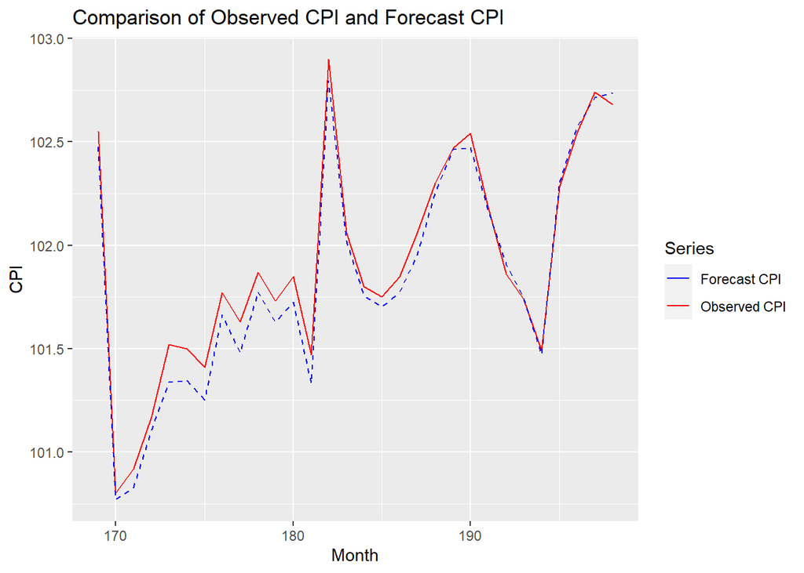

```r
# 显示原始CPI与预测CPI的比较图
print(comparison_plot)
```

```r
# 计算相应inflation rate：

# Extract two parts of CPI values whose lengths are both 30
predicted_cpi_values1 <- predicted_cpi[157:186]
predicted_cpi_values2 <- predicted_cpi[169:198]

# Derive the predicted inflation rate according to the formula using the two parts of CPI values
# Obtain the results of inflation rate prediction. ( from month 169 to month 198 ）【THE RESULTS OF OUR PROJECT】
inflation_rate_predictions <- log(predicted_cpi_values2) - log(predicted_cpi_values1)
print(inflation_rate_predictions)
```

```
##            1            2            3            4            5            6
##  0.007084380 -0.014865701 -0.014476630 -0.012030628 -0.006897470 -0.005256923
##            7            8            9           10           11           12
## -0.005106083  0.003178648 -0.004321410 -0.003198237 -0.006100537 -0.003485828
##           13           14           15           16           17           18
## -0.011192265  0.019885011  0.011712016  0.006397404  0.003561256  0.004201819
##           19           20           21           22           23           24
##  0.006906771  0.005799702  0.009636873  0.006846308  0.005292740  0.001769487
##           25           26           27           28           29           30
##  0.004060655 -0.012960931  0.002799261  0.007979065  0.009918871  0.009422493
```

```r
# Generate the historical inflation rate. ( from month 13 to month 168 )
inflation_rate_13to168 <- log(predicted_cpi[13:168]) - log(predicted_cpi[1:156])
month_inflation_rate_13to168 <- 13:168
historical_inflation_rate <- data.frame(month_inflation_rate_13to168, inflation_rate_13to168)
print(historical_inflation_rate)
```

```
##     month_inflation_rate_13to168 inflation_rate_13to168
## 1                             13           0.0275066458
## 2                             14           0.0187845365
## 3                             15           0.0205990609
## 4                             16           0.0273454539
## 5                             17           0.0360838757
## 6                             18           0.0457946552
## 7                             19           0.0466556916
## 8                             20           0.0426834918
## 9                             21           0.0397531743
## 10                            22           0.0242612579
## 11                            23          -0.0019436352
## 12                            24          -0.0077821404
## 13                            25          -0.0126769128
## 14                            26           0.0174761729
```

[output cut: 142 more lines]

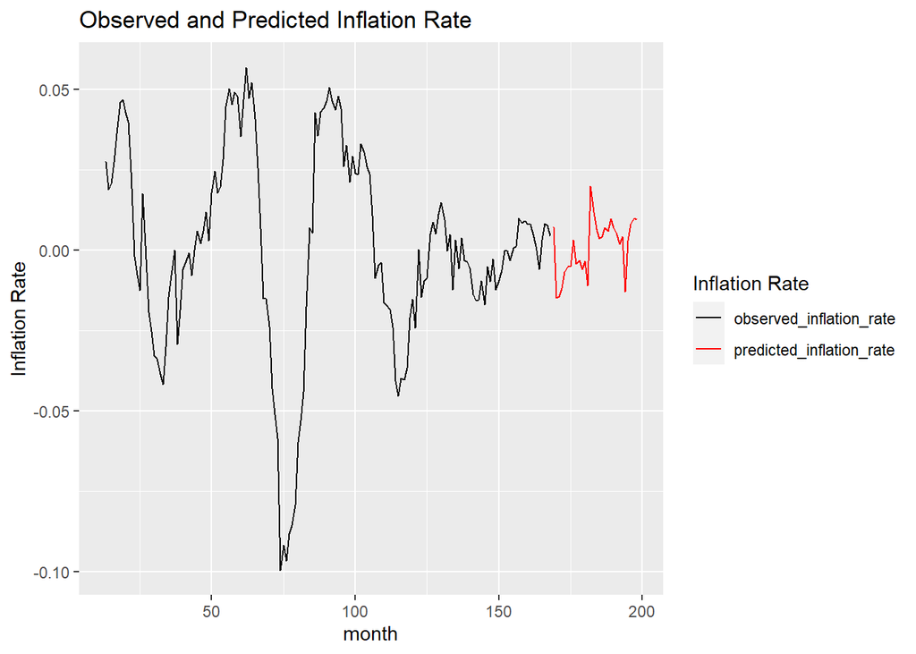

```r
# To generate plots, firstly we generate the observed inflation rates.
observed_inflation_rate <- data.frame(month = 13:168, Inflation_rate = inflation_rate_13to168)
# Secondly we generate the predicted inflation rates.
predicted_inflation_rate <- data.frame(month = 169:198, Inflation_rate = inflation_rate_predictions)
# Thirdly we combine these two data frames into one.
all_inflation_rate <- rbind(observed_inflation_rate, predicted_inflation_rate)
# Next we add a color variable.
all_inflation_rate$color <- ifelse(all_inflation_rate$month <= 168, "observed_inflation_rate", "predicted_inflation_rate")
# Lastly we generate the plot of inflation rate prediction based on CPI(random forest).
ggplot(all_inflation_rate, aes(x = month, y = Inflation_rate, color = color)) +
  geom_line() +
  labs(title = "Observed and Predicted Inflation Rate", y = "Inflation Rate") +
  scale_color_manual(name = "Inflation Rate", values = c("observed_inflation_rate" = "black", "predicted_inflation_rate" = "red"))
```

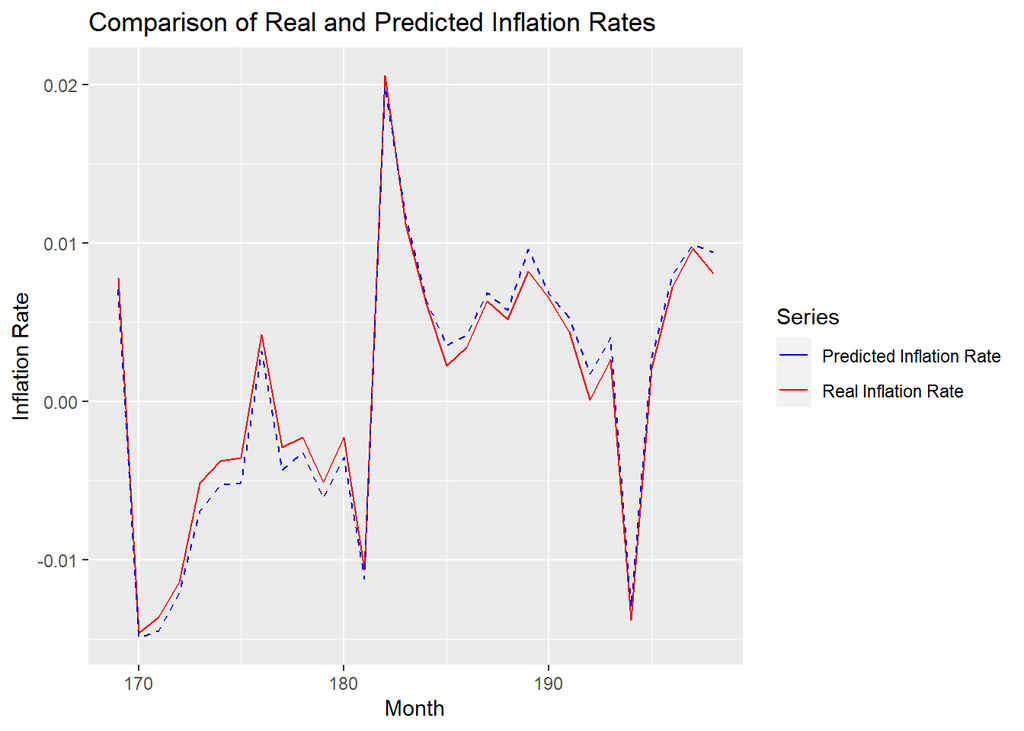

```r
# 计算出预测期30个月的真实inflation rate, 并绘制出预测期30个月真实inflation rate与预测inflation rate的对比图
real_cpi_1to198 <- rbind(cpi, real.cpi)

real_cpi_value1 <- real_cpi_1to198$CPI[1:186]
real_cpi_value2 <- real_cpi_1to198$CPI[13:198]

real_infaltion_rate <- log(real_cpi_value2)-log(real_cpi_value1)

real_final <- data.frame(real_infaltion_rate[157:186])
predicted_final <- data.frame(all_inflation_rate$Inflation_rate[157:186])
month_vector <- 169:198
real_final$month <- month_vector
predicted_final$month <- month_vector

comparison_plot_final <- ggplot() +
  geom_line(data = real_final, aes(x= month, y = real_infaltion_rate[157:186], color = "Real Inflation Rate"), linetype = "solid") +
  geom_line(data = predicted_final, aes(x = month, y = all_inflation_rate$Inflation_rate[157:186], color = "Predicted Inflation Rate"), linetype = "dashed") +
  labs(x = "Month", y = "Inflation Rate", title = "Comparison of Real and Predicted Inflation Rates") +
  scale_color_manual(values = c("blue", "red"), guide = guide_legend(title = "Series"))
print(comparison_plot_final)
```